# General Ross Macdonald Malaria Model With Spatial Diffusion and Delayed Differentials

Zach Dingels

8/16/2018

# 1 Misquito Movement Model

## 1.1 Variables

Let $\Omega$ denote a patch-based mosquito diffusion matrix, where $p_{i,j} \in \Omega$ is the fraction of mosquitoes moving to $i$ that initially began in $j$ over any given time step.

Let $M$ be our initial population density, where $M_i$ is the initial population in patch $i$

Let $g$ denote local mosquito death rates where the units are 1 / days.

Let $\Theta$ denote a matrix where $\theta_{i,j} \in \Theta$ denotes the number of adult mosquitoes that originated in patch $j$ that are now found in patch $i$.

```r
Omega <-  matrix(c( 0.75,  0.10,  0.15,
                    0.14,  0.75,  0.11,
                    0.09,  0.16,  0.75), nrow = 3, ncol = 3, byrow = TRUE)
M <- c(1000, 1025, 995) # Very sensitive
g <- c(0.1, 0.3, 0.2)
```

## 1.2 Discrete Model

```r
Theta_initial <- diag(M)

Theta <- function(t) {
  Omega %*% diag(1-g) %^% t %*% Theta_initial
}
```

## 1.3 Differential Model

```r
time <- seq(from=0, to=50, by = 0.1)
parameters <- c(r=Omega %*% diag(1-g))
state <- c(Theta = Theta(0))

dTheta <- function(t, state, parameters){
    with(
        as.list(c(state, parameters)),{
            r <- matrix(parameters, nrow=3)
            Theta <- matrix(state, nrow=3)
            dTheta <- t(r) %*% Theta - Theta
            return(list(as.vector(dTheta)))
        }
        )
}
```

## 1.4 Discrete Model Output

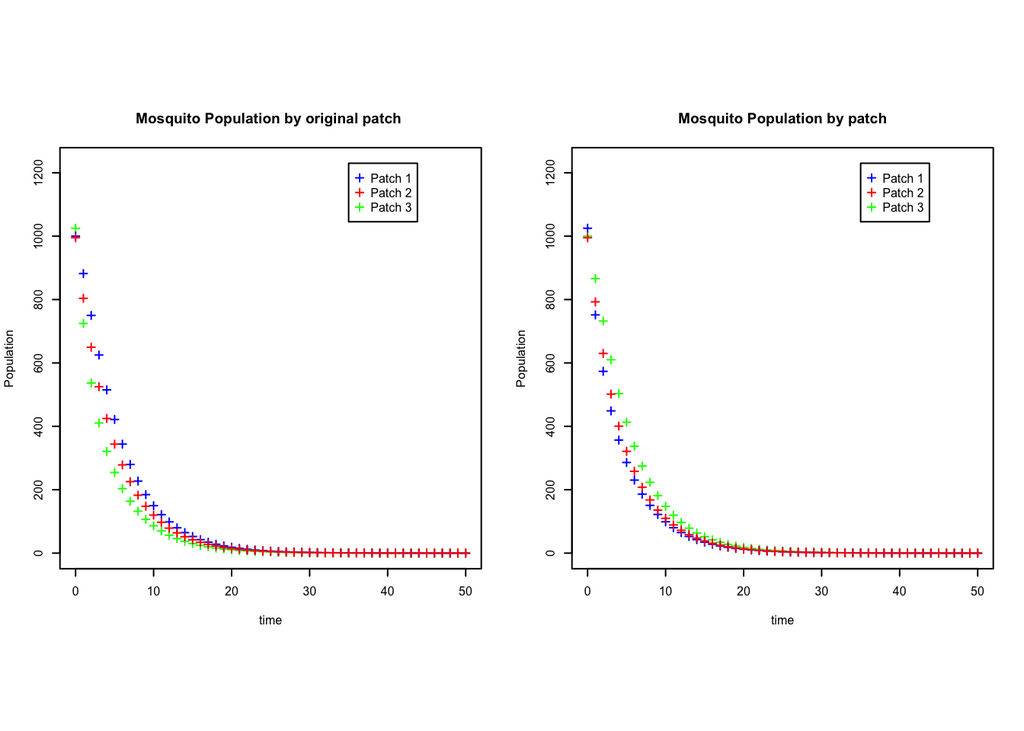

## 1.5 Discrete Model (Black) vs. Differential Model (Red)

The following plots compare the discrete and differential models for tracking misquito movement. We can see that both models verify each other because they are very similiar.

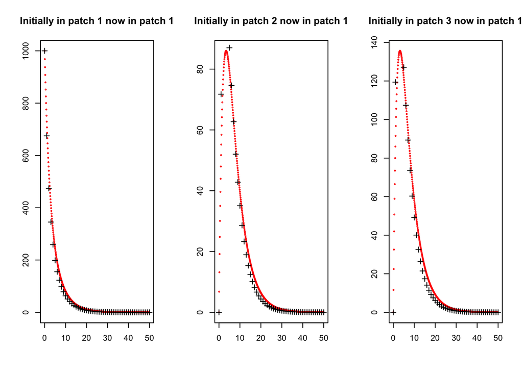

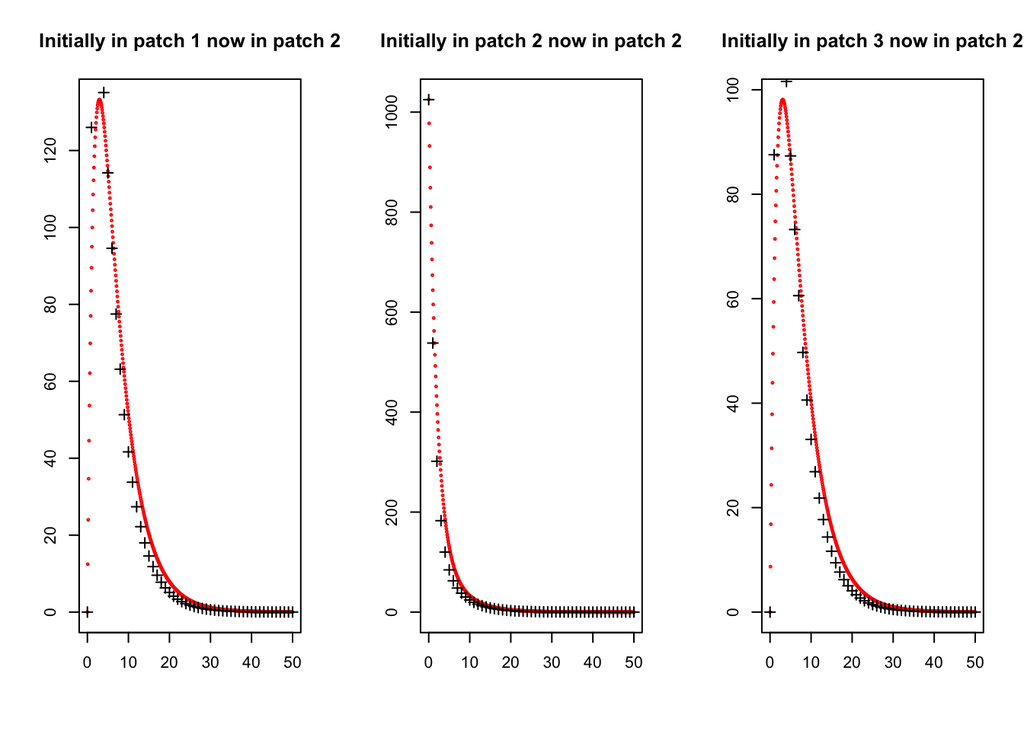

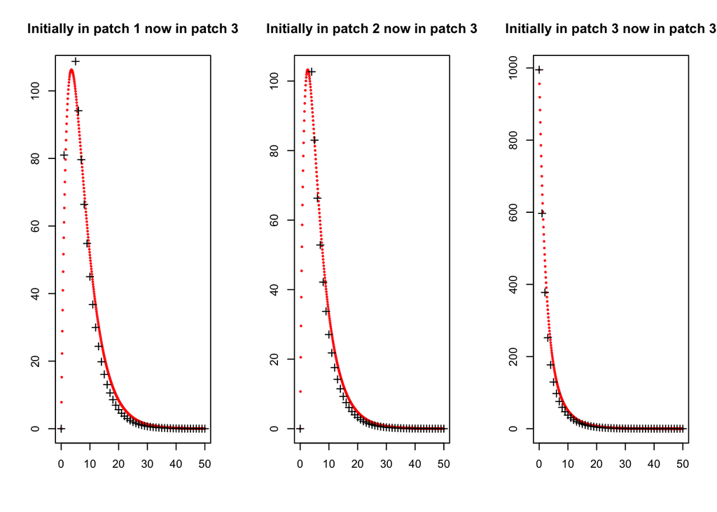

# 2 Time Delay Model for a Single Patch

Knowing that our differential model is accurate we will add in a time delay using delayed differential equations. The time delay will provide a better model because it will allow us to model the need for the malaria parasite to mature.

## 2.1 Variables

```r
# Lambda is a function that gives the number of new mosquitos per calendar day
lambda <- function(t) {
  return(0.1 + sin( (2 * pi * t) / 365 ) * 0.05)
}

a <- 0.3 # Number of bites on humans, per mosquito, per day
r <- 1/200 # Inverse of infectious period (1/days)
g <- 1/10 # Same as above but for mosquito death (1/days)
c <- 1/6  # The fraction of bites on infectious humans that lead to the transmission of the parasite to the biting mosquito.
tau <- 12 # The number of days required for the malaria parasite to mature
k <- 1 # the rate at which non-infected mosquitoes become infected by interacting with infectious humans.

H <- c(100)  # Human Population
X <- c(1)    # Infected Humans

M <- c(50) # Mosquito Population
Y <- c(0)  # Infected Mosquitos
Z <- c(0)  # Infectious Mosquitos
```

## 2.2 Delayed Differential Models

```r
times <- seq(from=0, to=365 * 3, by = 1)
parameters <- c(lambda=lambda, a=a, r=r, g=g, c=c, tau=tau, k=k)
state <- c(H=H, X=X , M=M , Y=Y , Z=Z)

d_dT <- function(t, state, parameters){
  with(
    as.list(c(state, parameters)),{
      if (t < 12) {
        return(list(rep(0, length(H) * 5)))
      } else {
        n_dims <- length(state) / 5
        H <- state[1:n_dims]
        X <- state[(n_dims + 1):(2 * n_dims)]

        M <- state[(2 * n_dims + 1):(3 * n_dims)]
        Y <- state[(3 * n_dims + 1):(4 * n_dims)]
        Z <- state[(4 * n_dims + 1):(5 * n_dims)]

        delay <- lagvalue(t - tau)

        H_tau <- delay[1:n_dims]
        X_tau <- delay[(n_dims + 1):(2 * n_dims)]

        M_tau <- delay[(2 * n_dims + 1):(3 * n_dims)]
        Y_tau <- delay[(3 * n_dims + 1):(4 * n_dims)]
        Z_tau <- delay[(4 * n_dims + 1):(5 * n_dims)]
      }

      dH_dt <- 0
      dX_dt <- a * Z / H * (H - X) - r * X

      dM_dt <- (lambda(t) - g) / 50 * M
      dY_dt <- a * c * X / H * (M - Y) - g * Y
      dZ_dt <- a * c * X_tau / H_tau * (M_tau - Y_tau) * exp(-g * tau) - g * Z
      return(list(as.vector(c(dH_dt, dX_dt, dM_dt, dY_dt, dZ_dt))))
        }
        )
}
```

## 2.3 Model Outputs

Our model has a constant human population of 100 and begins with an initial malaria infected individual. We also begin with 50 mosquitos, none of them are infected. Notice that:

- There is an initial 12 day delay before any of the mosquitos become infected.
- At the peak there are roughly 4.5 infectious mosquitos for every 15 infected mosquitos. This is expected, because a mosquito must live for 12 days after being infected with malaria before becoming infectious. The probability that mosquito lives this long is $e^{-0.1*12} \approx 0.3011$, which is almost the same as our ratio of infected to infectious mosquitos.
- At the peak there are aproximately 70 infected people. Given that the infection lasts for 200 days this is reasonable.

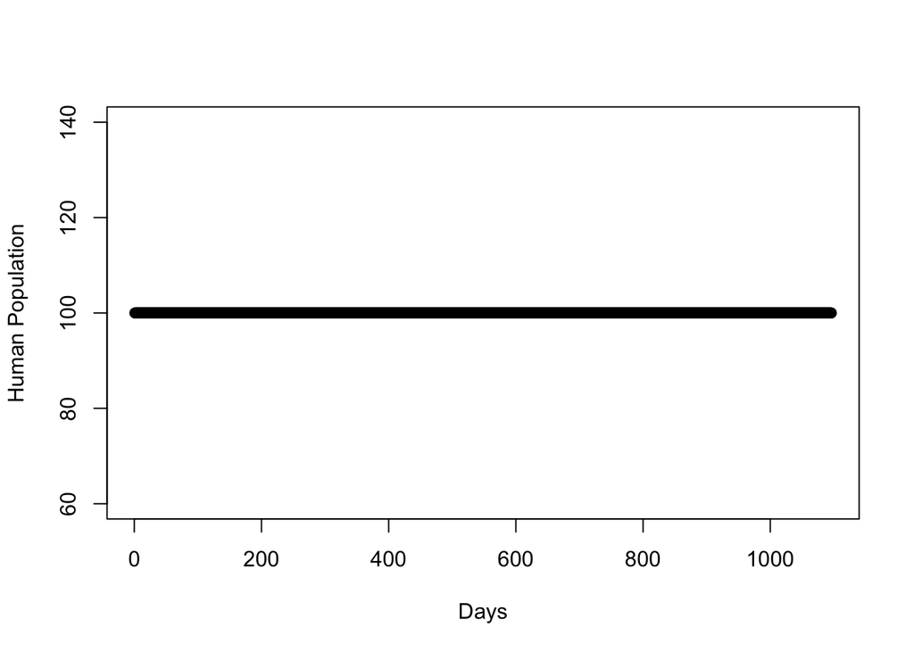

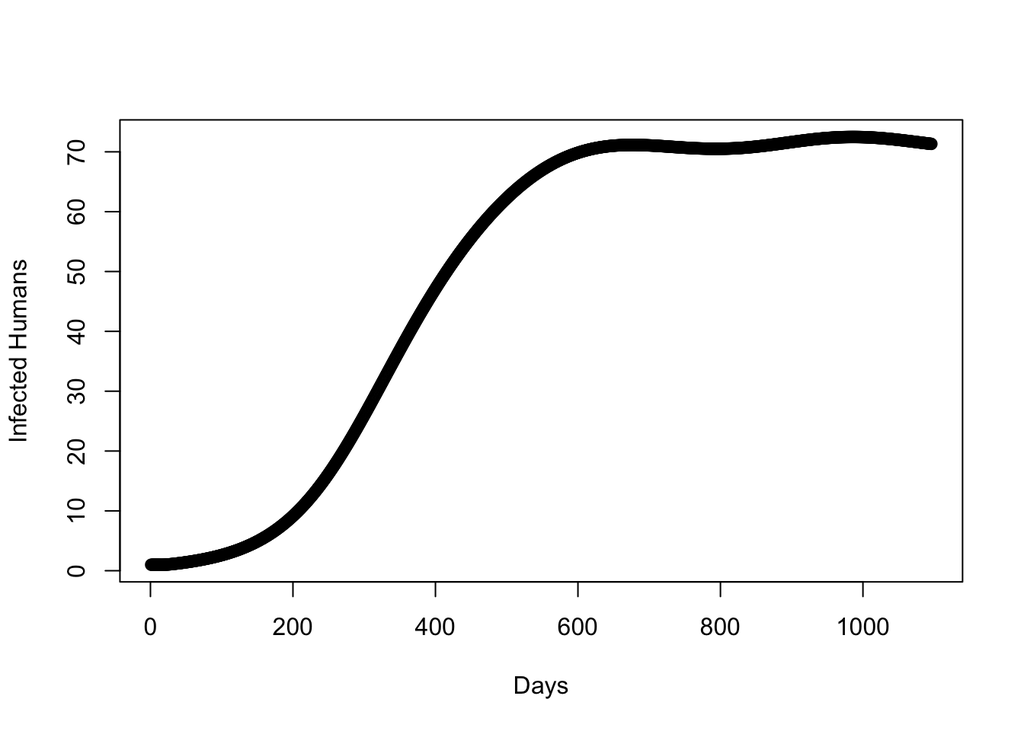

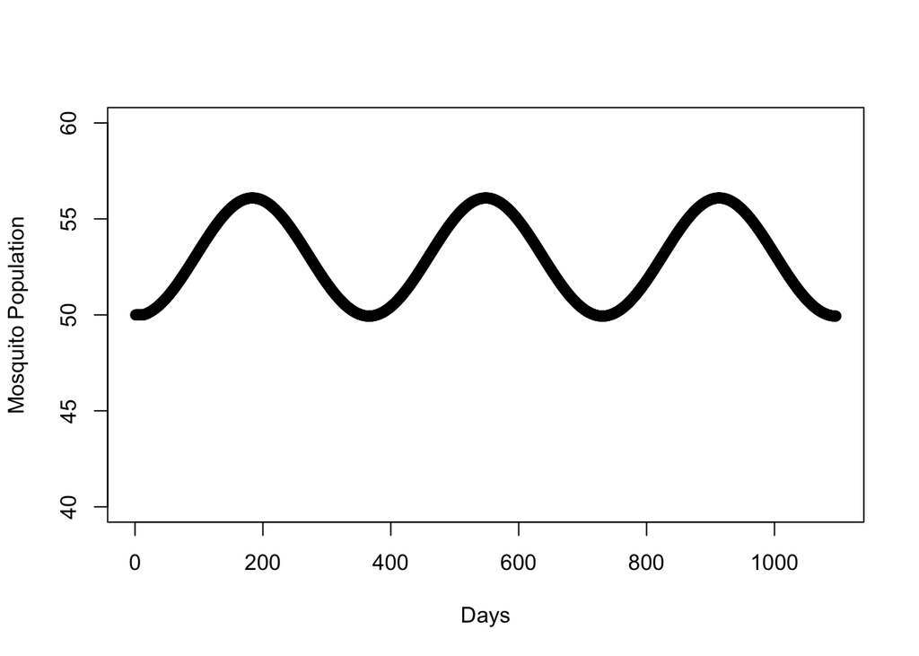

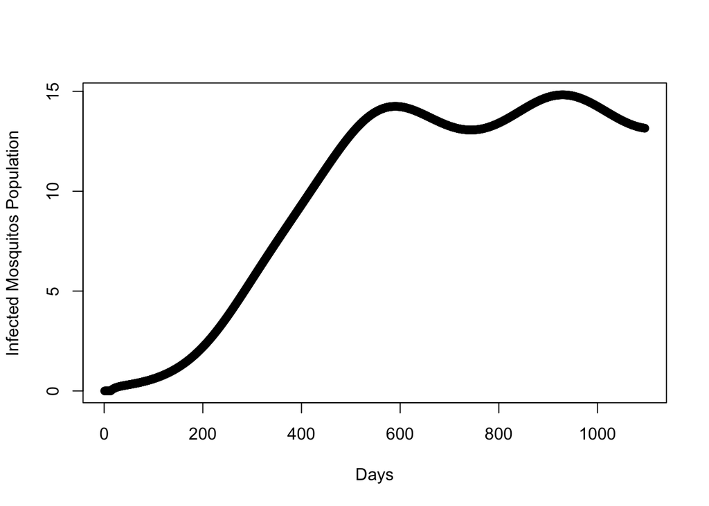

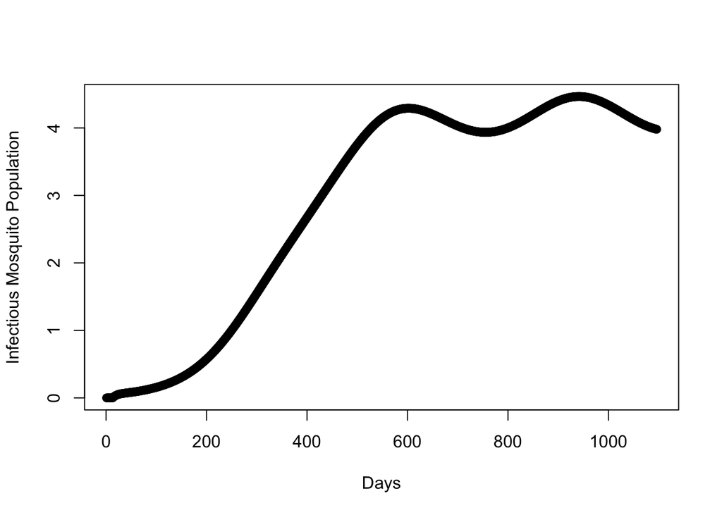

# 3 Delayed Differential and Spatial Model

## 3.1 Variables

### 3.1.1 Mosquito Variables

```r
lambda <- function(t) { # Rate at which mosquitos reproduce based on calendar day (t)
  return(0.1 + sin( (2 * pi * t) / 365 ) * 0.001)
}

M <- c(100, 200, 300)  # Mosquitos Population Density
Y <- c(50, 50, 50)       # Infected Mosquitos
Z <- c(10, 10, 10)    # Infectious Mosquitos

# Mosquito Movement Matrix (row i, column j = moving to patch i, currently in patch j) Units: % Mosquitos
Omega <-  matrix(c( 0.975,  0.014,  0.007,
                    0.010,  0.975,  0.018,
                    0.015,  0.011,  0.975), nrow = 3, ncol = 3, byrow = TRUE)

g <- c(1/10, 1/10, 1/10) # The rate at which mosquitoes die (1/days).
tau <- 12 # Incubation period for immature sporozoites (1/days)

# Mosquito Density Matrix (row i, column j = Currently in patch j, originally from patch i) Units: # Mosquitos
Theta <- function(t) {
  (Omega %*% diag(1-g, length(M))) %^% t %*% diag(M)
}
```

### 3.1.2 Human Variables

```r
H <- c(1000, 1050, 900)             # Human Population Density
X <- c(1000, 0, 0)                  # Infected Humans Density

# Human Movement Matrix (row i, column j = moving to patch i, currently in patch j) Units: % Humans
human_diffusion <- matrix(c(0.99990, 0.00002, 0.00001,
                            0.00009, 0.99997, 0.00004,
                            0.00001, 0.00001, 0.99995)
                          , nrow = 3, ncol = 3, byrow = TRUE)

r <- 1/200 # The rate at which humans shed recover or shed infection (1/days).
```

### 3.1.3 Ross Mcdonald Model Variables

```r
a <- 0.3 # Number of bites on humans, per mosquito, per day
c <- 1/6 # The fraction of bites on infectious humans that lead to the transmission of the parasite to the biting mosquito.
k <- 1 # the rate at which non-infected mosquitoes become infected by interacting with infectious humans.
```

## 3.2 Model

```r
years <- 20
times <- seq(from=0, to=365*years, by = 1)
parameters <- c(lambda=lambda, a=a, r=r, g=g, c=c, tau=tau, k=k)
state <- c(H=H, X=X , M=M , Y=Y , Z=Z, Theta=Theta(0))

GeRM <- function(t, state, parameters){
  with(
    as.list(c(state, parameters)),{
      # Number of patches
      n_dims <- length(H)

      # This sectiond deals with the time delays
      if (t < 12) {
        # Initial History Function:
        return(list(rep(0, length(H) * 5 + length(H) * length(H))))
      } else {
        # The states are passed in as a list. The vectors H,X, M, Y, and Z can easily be reconstructed.
        # The matrix Theta requires more than one line of code so it is constructed inside a function
        # that is located at the top of this document.
        H <- state[1:n_dims]
        X <- state[(n_dims + 1):(2 * n_dims)]
        M <- state[(2 * n_dims + 1):(3 * n_dims)]
        Y <- state[(3 * n_dims + 1):(4 * n_dims)]
        Z <- state[(4 * n_dims + 1):(5 * n_dims)]
        Theta <- construct_matrix('Theta', state, n_dims)

        delay <- lagvalue(t - tau)

        H_tau <- delay[1:n_dims]
        X_tau <- delay[(n_dims + 1):(2 * n_dims)]
        M_tau <- delay[(2 * n_dims + 1):(3 * n_dims)]
        Y_tau <- delay[(3 * n_dims + 1):(4 * n_dims)]
        Z_tau <- delay[(4 * n_dims + 1):(5 * n_dims)]
      }

      dH_dt <- rep(0, n_dims) + (human_diffusion - diag(3)) %*% H
      dX_dt <- a * Z / H * (H - X) - r * X

      dM_dt <- (lambda(t) - g) * M + (Omega - diag(3)) %*% M
      dY_dt <- a * c * X / H * (M - Y) - g * Y
      dZ_dt <- a * c * X_tau / H_tau * (M_tau - Y_tau) * exp(-g * tau) - g * Z
      dTheta_dt <- (Omega %*% diag(1-g, length(M))) %*% Theta - Theta
      return(list(as.vector(c(dH_dt, dX_dt, dM_dt, dY_dt, dZ_dt, dTheta_dt))))
    }
  )
}
```

## 3.3 Model Output

Aside from having multiple patches, the following plots should look familiar from the previous section. An additional plot is included at the end. It plots PR vs EIR. The paper “The entomological inoculation rate and Plasmodium falciparum infection in African children”, published in Nature, demonstrates that these values have a linear relationship on a logarithmic scale. Thus, the graphs purpose is to test the validity of the model. The plot initially shows no linear relationship but begins to as time passes. I believe this is due to spatial componenent. Initially, populations change drastically due to movement but balance out as time passes. Thus there is initially no linear relationship but as time passes a linear relationship becomes apparent.

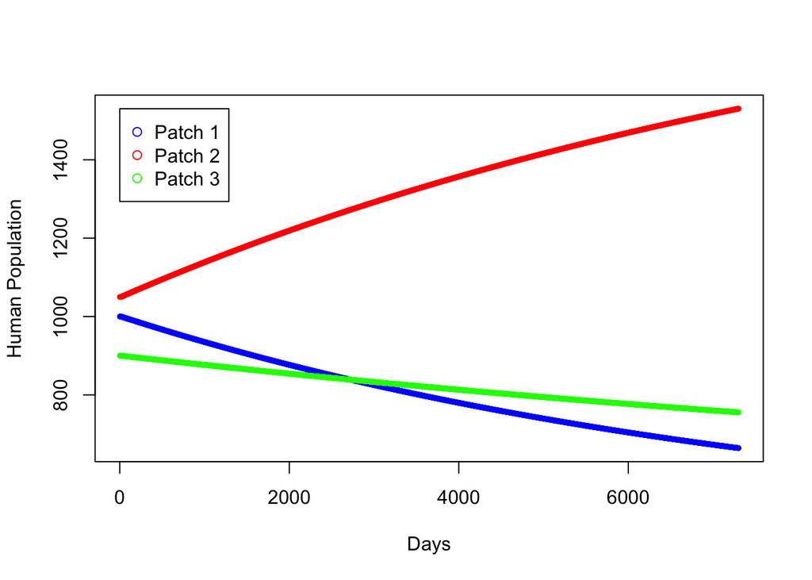

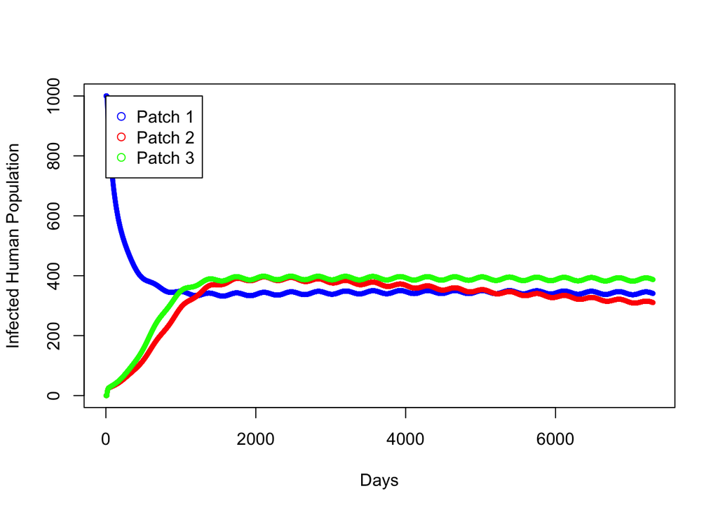

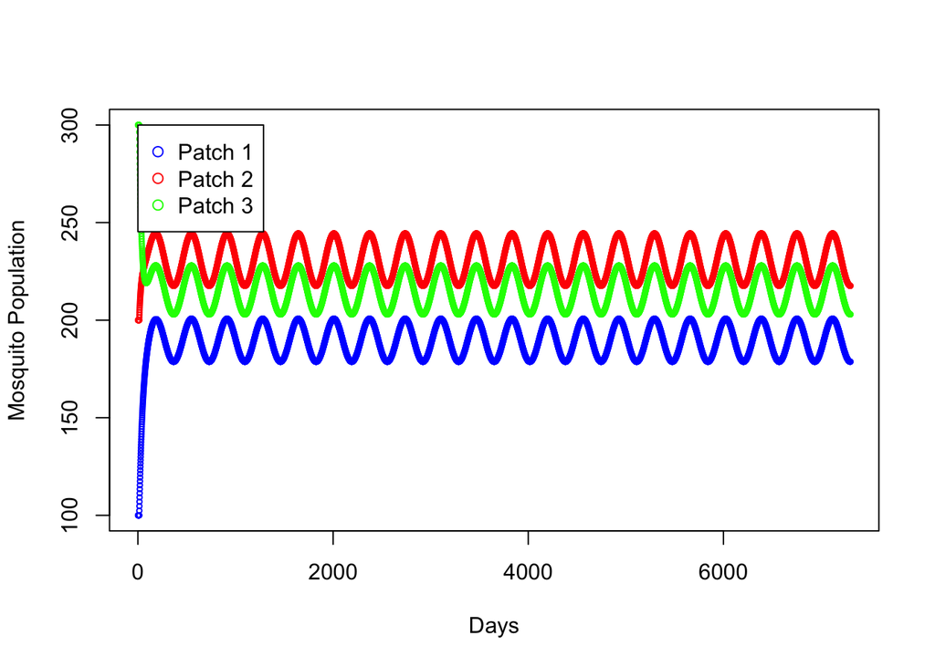

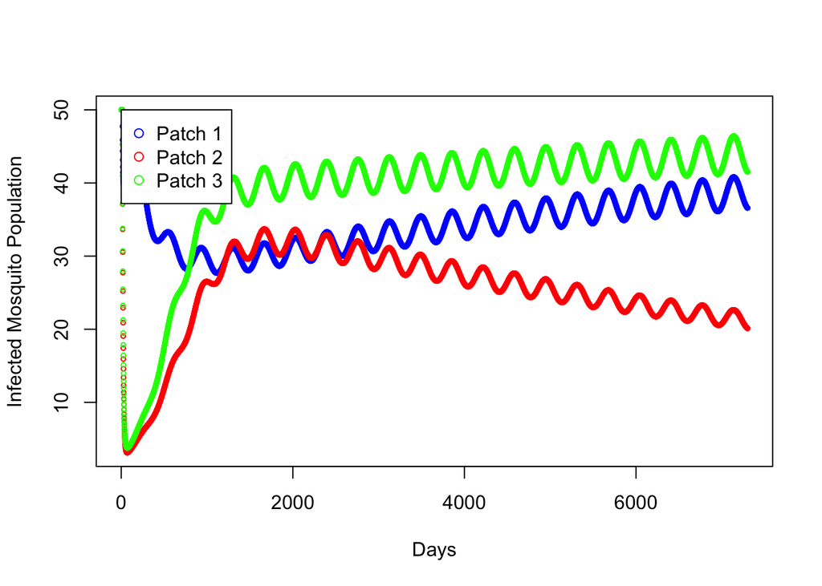

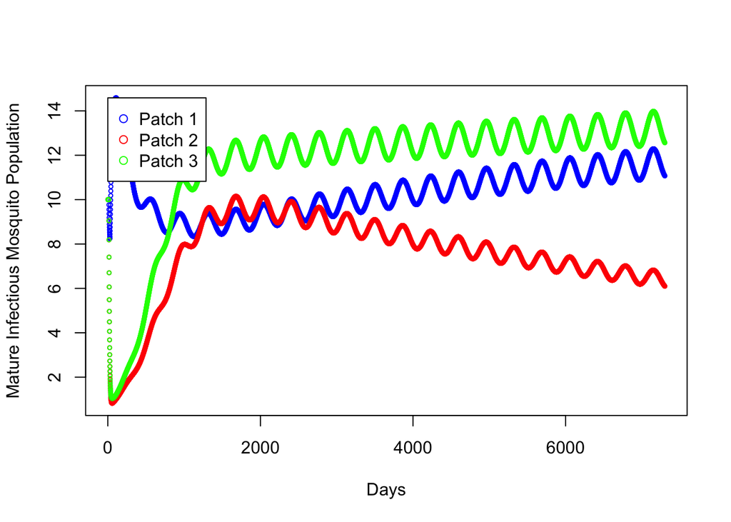

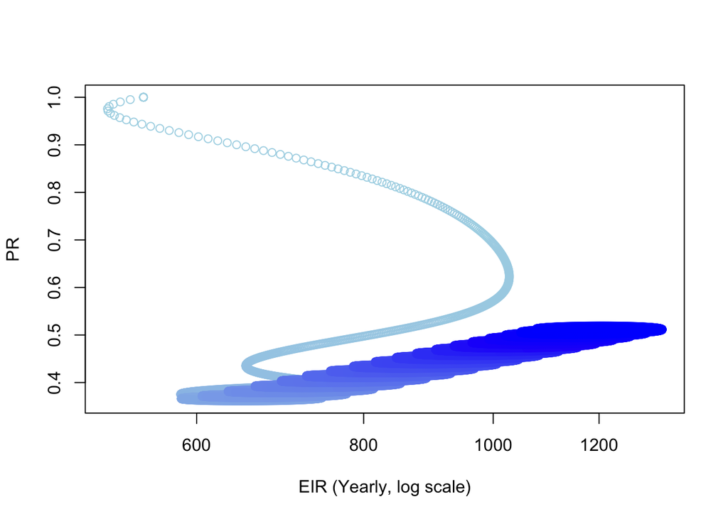